# House Price Prediction

Roquez Walker

2023-07-13

## Introduction:

Analysis on a house price predictions, report will be based on this competition from Kaggle.

Kaggle describes this competition as follows:

“Ask a home buyer to describe their dream house, and they probably won’t begin with the height of the basement ceiling or the proximity to an east-west railroad. But this playground competition’s dataset proves that much more influences price negotiations than the number of bedrooms or a white-picket fence.

With 79 explanatory variables describing (almost) every aspect of residential homes in Ames, Iowa, this competition challenges you to predict the final price of each home.”

https://www.kaggle.com/c/house-prices-advanced-regression-techniques

**Data Description:** The Ames, Iowa Housing dataset was compiled by Dean De Cock for use in data science education. This competition is a challenges to predict the final price of each home.

**Data Source:** www.kaggle.com/competitions/house-prices-advanced-regression-techniques/data

### Packages & Data Importing

```r
  library("knitr")
  library("tidyverse")
  library("ggplot2")
  library("plyr")
  library("dplyr")
  library("scales")
  library("corrplot")
  library("data.table")
  library("psych")
  library("caret")
  library("readr")
  library("Rmisc")
  library("randomForest")
  library("xgboost")
  library("ggrepel")
  library("gridExtra")
  library("pROC")
#Might use these, might not
  library("FeatureHashing")
  library("Matrix")
  library("stringr")
  library("Metrics")
  library("kernlab")
  library("mlbench")
```

```
## Rows: 1,460
## Columns: 81
## $ Id            <int> 1, 2, 3, 4, 5, 6, 7, 8, 9, 10, 11, 12, 13, 14, 15, 16, 1…
## $ MSSubClass    <int> 60, 20, 60, 70, 60, 50, 20, 60, 50, 190, 20, 60, 20, 20,…
## $ MSZoning      <chr> "RL", "RL", "RL", "RL", "RL", "RL", "RL", "RL", "RM", "R…
## $ LotFrontage   <int> 65, 80, 68, 60, 84, 85, 75, NA, 51, 50, 70, 85, NA, 91, …
## $ LotArea       <int> 8450, 9600, 11250, 9550, 14260, 14115, 10084, 10382, 612…
## $ Street        <chr> "Pave", "Pave", "Pave", "Pave", "Pave", "Pave", "Pave", …
## $ Alley         <chr> NA, NA, NA, NA, NA, NA, NA, NA, NA, NA, NA, NA, NA, NA, …
## $ LotShape      <chr> "Reg", "Reg", "IR1", "IR1", "IR1", "IR1", "Reg", "IR1", …
## $ LandContour   <chr> "Lvl", "Lvl", "Lvl", "Lvl", "Lvl", "Lvl", "Lvl", "Lvl", …
## $ Utilities     <chr> "AllPub", "AllPub", "AllPub", "AllPub", "AllPub", "AllPu…
## $ LotConfig     <chr> "Inside", "FR2", "Inside", "Corner", "FR2", "Inside", "I…
## $ LandSlope     <chr> "Gtl", "Gtl", "Gtl", "Gtl", "Gtl", "Gtl", "Gtl", "Gtl", …
## $ Neighborhood  <chr> "CollgCr", "Veenker", "CollgCr", "Crawfor", "NoRidge", "…
```

[output cut: 68 more lines]

## Cleaning & Formatting the data

```r
##Reformatting street data
train$paved[train$Street == "Pave"] <- 1
train$paved[train$Street != "Pave"] <- 0
##Lot shape
train$regshape[train$LotShape == "Reg"] <- 1
train$regshape[train$LotShape != "Reg"] <- 0
```

I continued this process of cleaning the data and converting variables to numeric rankings

### Analyzing the Trends in House Price Data

I chose to look at the trends in price purchased between the age of the house (year built), type and style of dwelling, quality, condition, and exterior of the homes.

Below I created a data frame to examine these trends in home prices (backup to not break my data)

```
## Rows: 1,460
## Columns: 5
## $ `train$Id`          <int> 1, 2, 3, 4, 5, 6, 7, 8, 9, 10, 11, 12, 13, 14, 15,…
## $ `train$YearBuilt`   <int> 2003, 1976, 2001, 1915, 2000, 1993, 2004, 1973, 19…
## $ `train$OverallQual` <int> 7, 6, 7, 7, 8, 5, 8, 7, 7, 5, 5, 9, 5, 7, 6, 7, 6,…
## $ `train$OverallCond` <int> 5, 8, 5, 5, 5, 5, 5, 6, 5, 6, 5, 5, 6, 5, 5, 8, 7,…
## $ `train$SalePrice`   <int> 208500, 181500, 223500, 140000, 250000, 143000, 30…
```

#### Trend in number of homes purchased by Price:

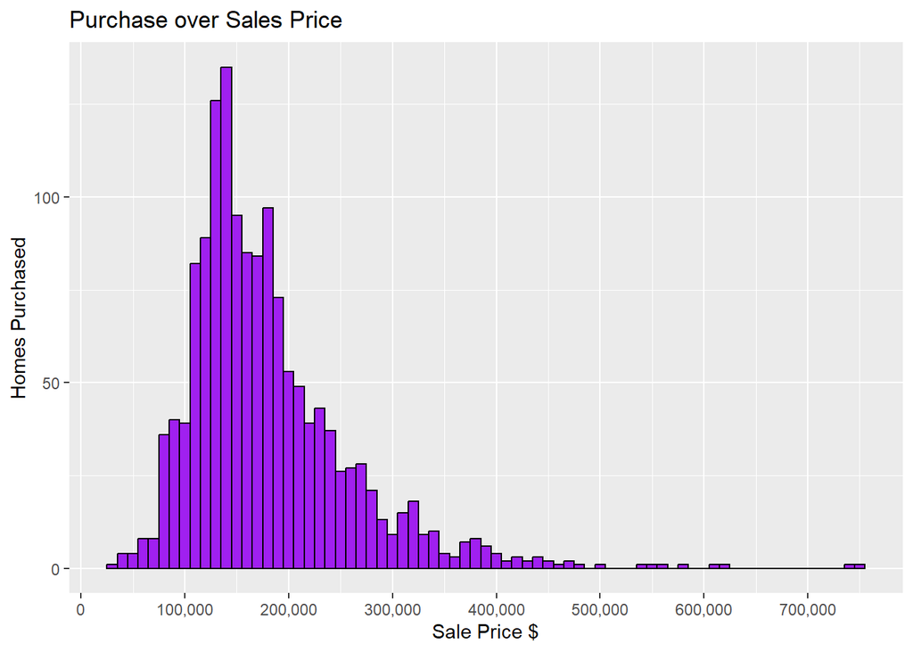

The market skews towards the right. It’s expected that people want affordable homes. Can be useful in making house price prediction with this in mind.

#### Trend in number of homes purchased by year:

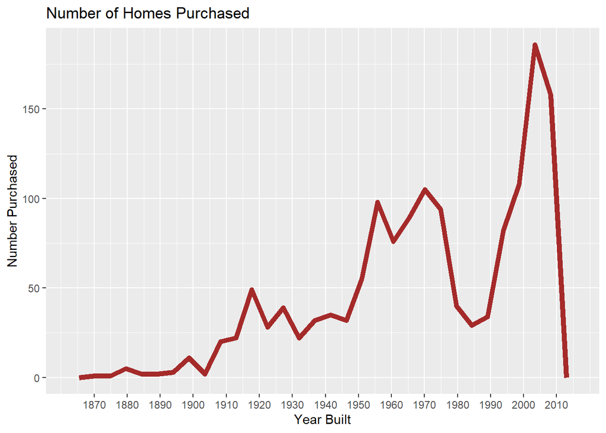

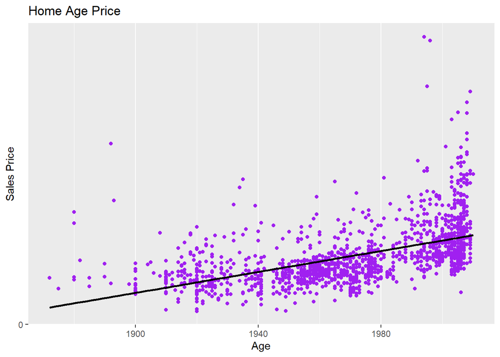

Positive correlation with Age (old houses are worth less).

#### Correlations with Sales Price

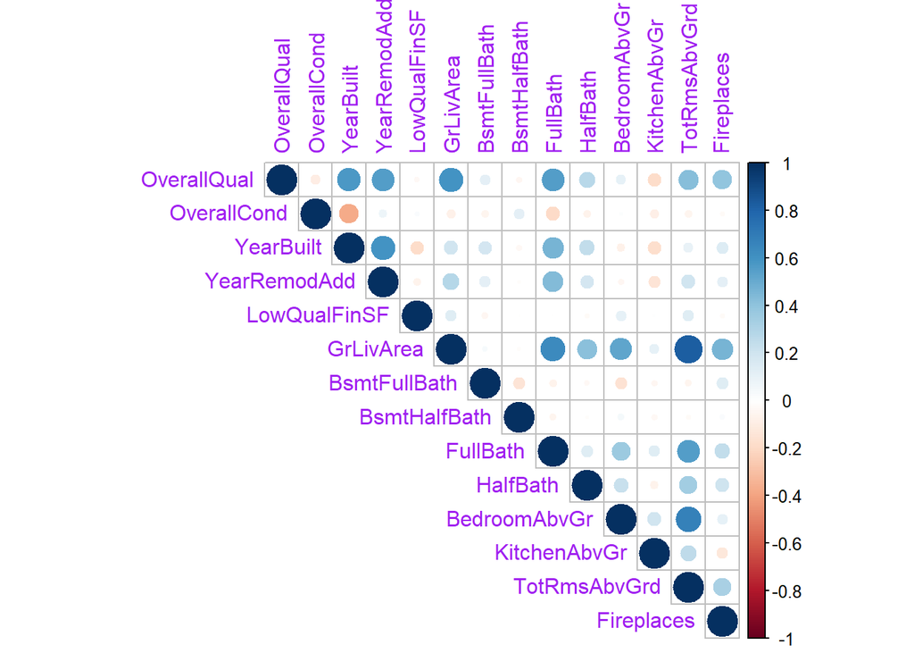

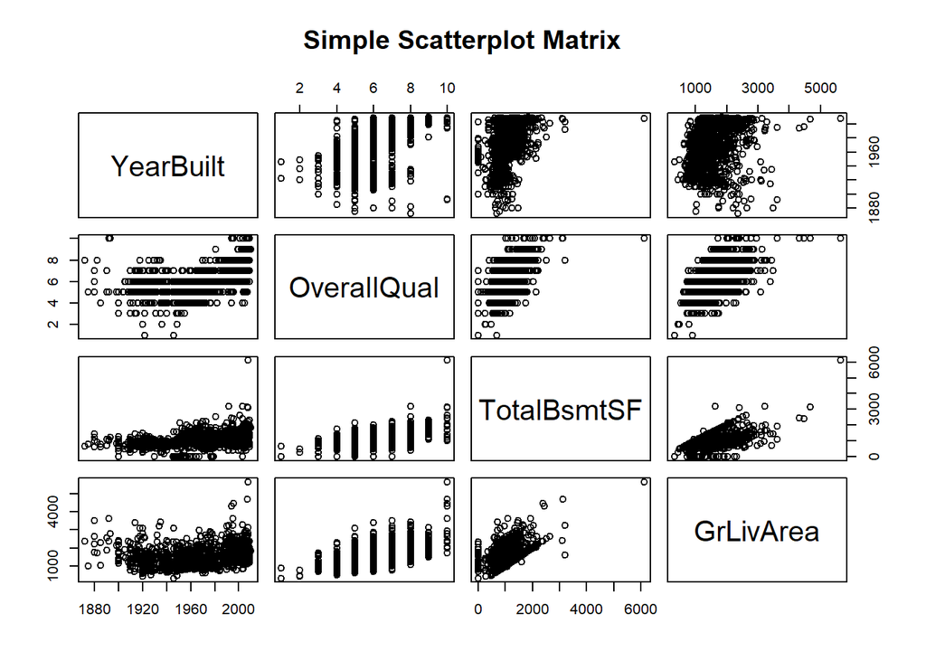

```r
pairs(~YearBuilt+OverallQual+TotalBsmtSF+GrLivArea,data=train,
      main="Simple Scatterplot Matrix")
```

#### Preparing data for modeling

```r
outcome <- train$SalePrice

partition <- createDataPartition(y = outcome,
                                 p = .5,
                                 list = F)

training <- train[partition, ]
testing <- train[-partition,]
```

### Modeling

```r
lm_model_15 <- lm(SalePrice ~., data=training)
summary(lm_model_15)
```

```
##
## Call:
## lm(formula = SalePrice ~ ., data = training)
##
## Residuals:
##     Min      1Q  Median      3Q     Max
## -139463  -10335     206   10450  128468
##
## Coefficients: (10 not defined because of singularities)
##                     Estimate Std. Error t value Pr(>|t|)
## (Intercept)        1.369e+06  1.417e+06   0.967 0.334060
## Id                -1.278e+00  1.915e+00  -0.667 0.504713
## MSSubClass        -6.060e+01  3.029e+01  -2.001 0.045817 *
## LotFrontage        1.181e+01  2.858e+01   0.413 0.679594
## LotArea            5.562e-01  8.925e-02   6.232 8.23e-10 ***
## OverallQual       -3.020e+05  9.826e+04  -3.073 0.002206 **
## OverallCond        6.919e+03  1.070e+03   6.464 1.99e-10 ***
## YearBuilt          1.282e+02  1.890e+02   0.678 0.497981
## YearRemodAdd      -5.948e+02  2.863e+02  -2.078 0.038114 *
## MasVnrArea         2.136e+01  7.341e+00   2.910 0.003737 **
## BsmtFinSF1        -2.126e+01  1.263e+01  -1.684 0.092691 .
## BsmtFinSF2        -2.869e+01  1.321e+01  -2.172 0.030225 *
## BsmtUnfSF         -4.102e+01  1.237e+01  -3.315 0.000968 ***
## TotalBsmtSF               NA         NA      NA       NA
## X1stFlrSF         -3.356e+01  1.259e+01  -2.666 0.007874 **
## X2ndFlrSF         -3.331e+01  1.297e+01  -2.568 0.010456 *
## LowQualFinSF      -3.933e+01  2.324e+01  -1.692 0.091059 .
## GrLivArea                 NA         NA      NA       NA
## BsmtFullBath       6.274e+02  2.384e+03   0.263 0.792503
## BsmtHalfBath       1.068e+03  3.949e+03   0.270 0.786872
## FullBath           3.417e+04  9.866e+03   3.464 0.000568 ***
## HalfBath           5.317e+01  2.450e+03   0.022 0.982690
## BedroomAbvGr      -3.493e+03  1.687e+03  -2.070 0.038871 *
## KitchenAbvGr      -7.430e+03  5.085e+03  -1.461 0.144473
## TotRmsAbvGrd       7.232e+02  1.183e+03   0.611 0.541336
## Fireplaces         4.037e+02  2.621e+03   0.154 0.877657
## GarageYrBlt        1.970e+00  4.784e+00   0.412 0.680676
## GarageCars         5.256e+03  2.936e+03   1.790 0.073898 .
## GarageArea         1.257e-01  9.543e+00   0.013 0.989493
## WoodDeckSF         3.430e+00  7.045e+00   0.487 0.626520
```

[output cut: 47 more lines]

```
## sale_cond          1.145e+04  3.009e+03   3.804 0.000156 ***
## zone               9.061e+03  2.234e+03   4.056 5.59e-05 ***
## alleypave         -3.617e+03  5.267e+03  -0.687 0.492568
## year_qual          2.377e+01  3.125e+01   0.760 0.447271
## year_r_qual        1.184e+02  5.302e+01   2.232 0.025934 *
## qual_bsmt          8.805e+00  1.933e+00   4.554 6.28e-06 ***
## livarea_qual       1.395e+01  1.724e+00   8.088 2.95e-15 ***
## qual_bath         -4.814e+03  1.574e+03  -3.058 0.002318 **
## qual_ext           3.426e+03  1.511e+03   2.267 0.023720 *
## ---
## Signif. codes:  0 '***' 0.001 '**' 0.01 '*' 0.05 '.' 0.1 ' ' 1
##
## Residual standard error: 21090 on 655 degrees of freedom
## Multiple R-squared:  0.9365, Adjusted R-squared:  0.9293
## F-statistic: 128.9 on 75 and 655 DF,  p-value: < 2.2e-16
```

```r
#could change include all " . " to "complete.cases(training)


#R-squared isn't too bad, indicates what percent of the variation in the outcome is explained using the model we designed.
```

```r
lm_model_15 <- lm(SalePrice ~ MSSubClass+LotArea+BsmtUnfSF+
                    X1stFlrSF+X2ndFlrSF+GarageCars+
                   WoodDeckSF+nbhd_price_level+
                  exterior_cond+pos_features_1+
                    bsmt_exp+kitchen+housefunction+pool_good+sale_cond+
                   qual_ext+qual_bsmt, data=training)

summary(lm_model_15)
```

```
##
## Call:
## lm(formula = SalePrice ~ MSSubClass + LotArea + BsmtUnfSF + X1stFlrSF +
##     X2ndFlrSF + GarageCars + WoodDeckSF + nbhd_price_level +
##     exterior_cond + pos_features_1 + bsmt_exp + kitchen + housefunction +
##     pool_good + sale_cond + qual_ext + qual_bsmt, data = training)
##
## Residuals:
##     Min      1Q  Median      3Q     Max
## -134671  -14063     748   14223  191315
##
## Coefficients: (1 not defined because of singularities)
##                    Estimate Std. Error t value Pr(>|t|)
## (Intercept)      -5.849e+04  1.125e+04  -5.200 2.61e-07 ***
## MSSubClass       -1.601e+02  2.412e+01  -6.639 6.25e-11 ***
## LotArea           5.043e-01  9.523e-02   5.296 1.58e-07 ***
## BsmtUnfSF        -2.336e+01  2.498e+00  -9.352  < 2e-16 ***
## X1stFlrSF         4.495e+01  5.143e+00   8.741  < 2e-16 ***
## X2ndFlrSF         5.828e+01  2.916e+00  19.988  < 2e-16 ***
## GarageCars        4.853e+03  1.661e+03   2.922 0.003585 **
## WoodDeckSF        1.169e+01  7.946e+00   1.471 0.141631
## nbhd_price_level         NA         NA      NA       NA
## exterior_cond    -1.819e+04  5.416e+03  -3.359 0.000824 ***
## pos_features_1    5.202e+03  7.988e+03   0.651 0.515065
## bsmt_exp          5.775e+03  1.084e+03   5.328 1.33e-07 ***
## kitchen           9.986e+03  2.330e+03   4.286 2.07e-05 ***
## housefunction     1.545e+04  4.325e+03   3.572 0.000378 ***
## pool_good         2.112e+05  2.730e+04   7.736 3.51e-14 ***
## sale_cond         1.660e+04  2.467e+03   6.729 3.50e-11 ***
## qual_ext          4.265e+03  6.380e+02   6.685 4.66e-11 ***
## qual_bsmt         7.124e+00  7.813e-01   9.118  < 2e-16 ***
## ---
## Signif. codes:  0 '***' 0.001 '**' 0.01 '*' 0.05 '.' 0.1 ' ' 1
##
## Residual standard error: 25720 on 714 degrees of freedom
## Multiple R-squared:  0.8971, Adjusted R-squared:  0.8948
## F-statistic: 388.9 on 16 and 714 DF,  p-value: < 2.2e-16
```

```r
#This is the model with the important info
```

```r
prediction <- predict(lm_model_15, testing, type="response")
model_output <- cbind(testing, prediction)

model_output$log_prediction <- log(model_output$prediction)
model_output$log_SalePrice <- log(model_output$SalePrice)

#Test with RMSE

rmse(model_output$log_SalePrice,model_output$log_prediction)
```

```
## [1] 0.1713025
```

Next I’ll use the Random Forest package with the variables and Linear Model

```r
## A Random Forest
model_1 <- randomForest(SalePrice ~ ., data = training)

#Predict using the test set
prediction <- predict(model_1, testing)
model_output <- cbind(testing, prediction)

model_output$log_prediction <- log(model_output$prediction)
model_output$log_SalePrice <- log(model_output$SalePrice)

#Test with RMSE

rmse(model_output$log_SalePrice,model_output$log_prediction)
```

```
## [1] 0.1520379
```

xgboost

```r
#Assemble and format the data
training$log_SalePrice <- log(training$SalePrice)
testing$log_SalePrice <- log(testing$SalePrice)

#Create matrices from the data frames
trainData<- as.matrix(training, rownames.force=NA)
testData<- as.matrix(testing, rownames.force=NA)

#Turn the matrices into sparse matrices
train2 <- as(trainData, "sparseMatrix")
test2 <- as(testData, "sparseMatrix")

#Cross Validate the model
vars <- c(2:37, 39:86) #choose the columns we want to use in the prediction matrix

#Convert to xgb.DMatrix format
trainD <- xgb.DMatrix(data = train2[,vars], label = train2[,"SalePrice"])

#Cross validate the model
cv.sparse <- xgb.cv(data = trainD,
                    nrounds = 600,
                    min_child_weight = 0,
                    max_depth = 10,
                    eta = 0.02,
                    subsample = .7,
                    colsample_bytree = .7,
                    booster = "gbtree",
                    eval_metric = "rmse",
                    verbose = TRUE,
                    print_every_n = 50,
                    nfold = 4,
                    nthread = 2,
                    objective="reg:linear")
```

[output not shown]

Training the model

```r
#Train the model
#Choose the parameters for the model
param <- list(colsample_bytree = .7,
              subsample = .7,
              booster = "gbtree",
              max_depth = 10,
              eta = 0.02,
              eval_metric = "rmse",
              objective="reg:linear")


#Train the model using those parameters
bstSparse <-
  xgb.train(params = param,
            data = trainD,
            nrounds = 600,
            watchlist = list(train = trainD),
            verbose = TRUE,
            print_every_n = 50,
            nthread = 2)
```

```
## [08:28:07] WARNING: src/objective/regression_obj.cu:213: reg:linear is now deprecated in favor of reg:squarederror.
```

Test the RMSE

```r
testD <- xgb.DMatrix(data = test2[,vars])
#Column names must match the inputs EXACTLY
prediction <- predict(bstSparse, testD) #Make the prediction based on the half of the training data set aside

#Put testing prediction and test dataset all together
test3 <- as.data.frame(as.matrix(test2))
prediction <- as.data.frame(as.matrix(prediction))
colnames(prediction) <- "prediction"
model_output <- cbind(test3, prediction)

model_output$log_prediction <- log(model_output$prediction)
model_output$log_SalePrice <- log(model_output$SalePrice)

#Test with RMSE

rmse(model_output$log_SalePrice,model_output$log_prediction)
```

```
## [1] 0.1439106
```

Retraining on the full sample

```r
rm(bstSparse)

#Create matrices from the data frames
retrainData<- as.matrix(train, rownames.force=NA)

#Turn the matrices into sparse matrices
retrain <- as(retrainData, "sparseMatrix")

param <- list(colsample_bytree = .7,
              subsample = .7,
              booster = "gbtree",
              max_depth = 10,
              eta = 0.02,
              eval_metric = "rmse",
              objective="reg:linear")

retrainD <- xgb.DMatrix(data = retrain[,vars], label = retrain[,"SalePrice"])

#retrain the model using those parameters
bstSparse <-
  xgb.train(params = param,
            data = retrainD,
            nrounds = 600,
            watchlist = list(train = trainD),
            verbose = TRUE,
            print_every_n = 50,
            nthread = 2)
```

```
## [08:28:10] WARNING: src/objective/regression_obj.cu:213: reg:linear is now deprecated in favor of reg:squarederror.
```

## Preparing the prediction data

Next I cleaned and reformatted the test data set for prediction preparation. Also triple checked that column sizes and names were sustained.

```r
#Data preformatted for xgboost
predict <- as.data.frame(test) #Get the dataset formatted as a frame for later combining

#Create matrices from the data frames
predData<- as.matrix(predict, rownames.force=NA)

#Turn the matrices into sparse matrices
predicting <- as(predData, "sparseMatrix")
```

```r
#making sure the training sample and prediction sample have the same variables
colnames(train[,c(2:37, 39:86)])
```

```
##  [1] "MSSubClass"        "LotFrontage"       "LotArea"
##  [4] "OverallQual"       "OverallCond"       "YearBuilt"
##  [7] "YearRemodAdd"      "MasVnrArea"        "BsmtFinSF1"
## [10] "BsmtFinSF2"        "BsmtUnfSF"         "TotalBsmtSF"
## [13] "X1stFlrSF"         "X2ndFlrSF"         "LowQualFinSF"
## [16] "GrLivArea"         "BsmtFullBath"      "BsmtHalfBath"
## [19] "FullBath"          "HalfBath"          "BedroomAbvGr"
## [22] "KitchenAbvGr"      "TotRmsAbvGrd"      "Fireplaces"
## [25] "GarageYrBlt"       "GarageCars"        "GarageArea"
## [28] "WoodDeckSF"        "OpenPorchSF"       "EnclosedPorch"
## [31] "X3SsnPorch"        "ScreenPorch"       "PoolArea"
## [34] "MiscVal"           "MoSold"            "YrSold"
## [37] "paved"             "regshape"          "flat"
## [40] "pubutil"           "gentle_slope"      "culdesac_fr3"
## [43] "nbhd_price_level"  "pos_features_1"    "pos_features_2"
## [46] "twnhs_end_or_1fam" "house_style_level" "roof_hip_shed"
## [49] "roof_matl_hi"      "exterior_1"        "exterior_2"
## [52] "exterior_mason_1"  "exterior_cond"     "exterior_cond2"
## [55] "found_concrete"    "bsmt_cond1"        "bsmt_cond2"
## [58] "bsmt_exp"          "bsmt_fin1"         "bsmt_fin2"
## [61] "gasheat"           "heatqual"          "air"
## [64] "standard_electric" "kitchen"           "fire"
## [67] "gar_attach"        "gar_finish"        "garqual"
## [70] "garqual2"          "paved_drive"       "housefunction"
## [73] "pool_good"         "priv_fence"        "sale_cat"
## [76] "sale_cond"         "zone"              "alleypave"
## [79] "year_qual"         "year_r_qual"       "qual_bsmt"
## [82] "livarea_qual"      "qual_bath"         "qual_ext"
```

```r
vars <- c("MSSubClass","LotFrontage","LotArea","OverallQual","OverallCond","YearBuilt",
          "YearRemodAdd","MasVnrArea","BsmtFinSF1","BsmtFinSF2","BsmtUnfSF","TotalBsmtSF"   ,
          "X1stFlrSF","X2ndFlrSF","LowQualFinSF","GrLivArea","BsmtFullBath","BsmtHalfBath"  ,
          "FullBath","HalfBath","BedroomAbvGr","KitchenAbvGr","TotRmsAbvGrd","Fireplaces"     ,
          "GarageYrBlt","GarageCars","GarageArea","WoodDeckSF","OpenPorchSF","EnclosedPorch"    ,
          "X3SsnPorch","ScreenPorch","PoolArea","MiscVal","MoSold","YrSold",
          "paved","regshape","flat","pubutil","gentle_slope","culdesac_fr3"     ,
          "nbhd_price_level" , "pos_features_1","pos_features_2","twnhs_end_or_1fam","house_style_level", "roof_hip_shed"    ,
          "roof_matl_hi","exterior_1","exterior_2","exterior_mason_1","exterior_cond","exterior_cond2"   ,
          "found_concrete","bsmt_cond1","bsmt_cond2","bsmt_exp","bsmt_fin1","bsmt_fin2"    ,
          "gasheat","heatqual","air","standard_electric", "kitchen","fire",
          "gar_attach","gar_finish","garqual","garqual2","paved_drive","housefunction",
          "pool_good","priv_fence","sale_cat","sale_cond","zone","alleypave",
          "year_qual","year_r_qual","qual_bsmt","livarea_qual","qual_bath", "qual_ext")

#colnames(predicting)
colnames(predicting[,vars])
```

```
##  [1] "MSSubClass"        "LotFrontage"       "LotArea"
##  [4] "OverallQual"       "OverallCond"       "YearBuilt"
##  [7] "YearRemodAdd"      "MasVnrArea"        "BsmtFinSF1"
## [10] "BsmtFinSF2"        "BsmtUnfSF"         "TotalBsmtSF"
## [13] "X1stFlrSF"         "X2ndFlrSF"         "LowQualFinSF"
## [16] "GrLivArea"         "BsmtFullBath"      "BsmtHalfBath"
## [19] "FullBath"          "HalfBath"          "BedroomAbvGr"
## [22] "KitchenAbvGr"      "TotRmsAbvGrd"      "Fireplaces"
## [25] "GarageYrBlt"       "GarageCars"        "GarageArea"
## [28] "WoodDeckSF"        "OpenPorchSF"       "EnclosedPorch"
## [31] "X3SsnPorch"        "ScreenPorch"       "PoolArea"
## [34] "MiscVal"           "MoSold"            "YrSold"
## [37] "paved"             "regshape"          "flat"
## [40] "pubutil"           "gentle_slope"      "culdesac_fr3"
## [43] "nbhd_price_level"  "pos_features_1"    "pos_features_2"
## [46] "twnhs_end_or_1fam" "house_style_level" "roof_hip_shed"
## [49] "roof_matl_hi"      "exterior_1"        "exterior_2"
## [52] "exterior_mason_1"  "exterior_cond"     "exterior_cond2"
## [55] "found_concrete"    "bsmt_cond1"        "bsmt_cond2"
## [58] "bsmt_exp"          "bsmt_fin1"         "bsmt_fin2"
## [61] "gasheat"           "heatqual"          "air"
## [64] "standard_electric" "kitchen"           "fire"
## [67] "gar_attach"        "gar_finish"        "garqual"
## [70] "garqual2"          "paved_drive"       "housefunction"
## [73] "pool_good"         "priv_fence"        "sale_cat"
## [76] "sale_cond"         "zone"              "alleypave"
## [79] "year_qual"         "year_r_qual"       "qual_bsmt"
## [82] "livarea_qual"      "qual_bath"         "qual_ext"
```

### Predictions & Summary

```r
#Column names must match the inputs EXACTLY
prediction <- predict(bstSparse, predicting[,vars])

prediction <- as.data.frame(as.matrix(prediction))  #Get the dataset formatted as a frame for later combining
colnames(prediction) <- "prediction"
model_output <- cbind(predict, prediction) #Combine the prediction output with the rest of the set

sub2 <- data.frame(Id = model_output$Id, SalePrice = model_output$prediction)
length(model_output$prediction)
```

```
## [1] 1459
```

```r
head(sub2$SalePrice)
```

```
## [1] 126653.4 158410.1 175752.0 186872.6 187439.9 174856.6
```

In summary, we can see that the sales price of the homes can be predicted using the data provided. Here’s a comparison between the the data sets.

Original Data

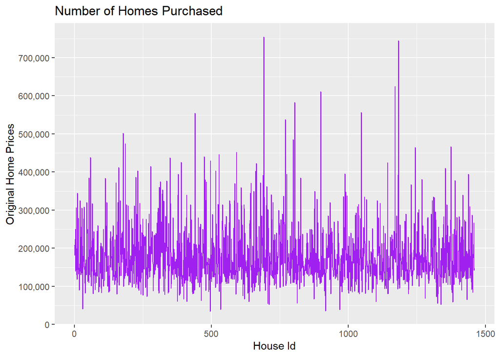

Predicted Data

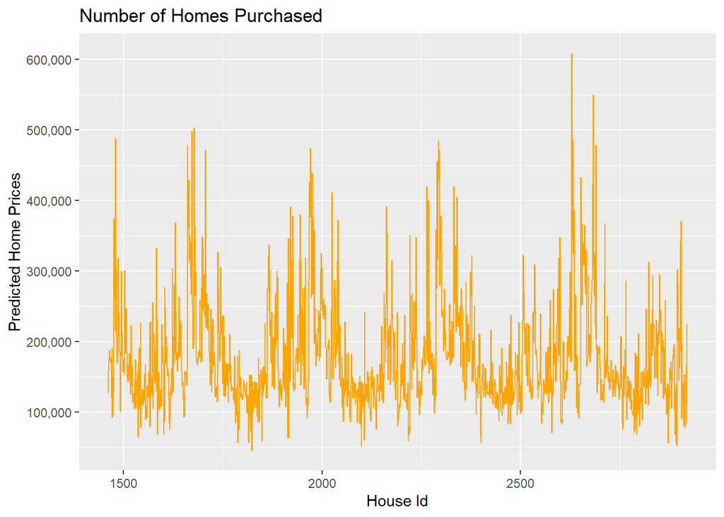

The predictions were made after cleaning, formatting, normalizing, and using different statistical models to get a sufficient estimate of home prices.

Thank you for reading!